# Deng data: finalizing analysis in reference to Guo data

Joyce Hsiao

2016-10-27

## Objective

In this document, we analyzed the blastocyst samples including only the 48 genes that were used in differentiating cell types during blastocyst stages in Guo et al., 2010. We applied the GoM with K = 3 and investigated the expression profile of the 48 genes under K = 3 with cell samples re-ordered according to topic proportions.

Load Deng data

```r
library(singlecellRNAseqData)
MouseDengESC <- get(data("MouseDengESC"))
meta_data <- pData(MouseDengESC)
```

Compute index variable for the blastocyst cell samples

```r
is_blastocyst <- which(meta_data$cell_type == "earlyblast"|
                        meta_data$cell_type == "midblast" |
                        meta_data$cell_type == "lateblast")
```

Import list of 48 genes identified in Guo et al.

```r
guo_genes <- c("Creb3l2", "Tcf23", "Snai1", "Pdgfra", "Gata4", "Sox13",
               "Klf5", "Tcfap2c", "Gapdh", "Actb", "Pdgfa", "Msc", "Hand1",
               "Runx1", "Gata6", "Fgfr2", "Dab2", "Msx2", "Hnf4a", "Pou5f1",
               "Utf1", "Sall4", "Ahcy", "Sox17", "Klf4", "Fgf4", "Klf2",
               "Esrrb", "Nanog", "Bmp4", "Sox2", "Fn1", "Pecam1", "Tspan8",
               "Dppa1", "Lcp1", "Aqp3", "Id2", "Krt8", "Cebpa", "Eomes",
               "Gata3", "Mbnl3", "Tcfap2a", "Grhl1", "Atp12a", "Grhl2", "Cdx2")
```

Normalize the count data. Use the method implemented in voom/limma.

```r
counts <- exprs(MouseDengESC)
lib_size <- colSums(counts)
expr_log2cpm <- t(log2(t(counts + 0.5)/(lib_size + 1) * 1e+06))
```

Create a subset of 48 genes included in Guo et al., 2010.

```r
ind_match <- match(guo_genes, rownames(counts))

expr_log2cpm_guo <- expr_log2cpm[ind_match,]
```

## K = 3

Load GoM results. Fitting k = 3 on the blastocyst samples and including 48 marker genes.

```r
fit <- get(load("../rdas/deng_guo_blast_48_genes_k_3.rda"))
```

### Make structure plot

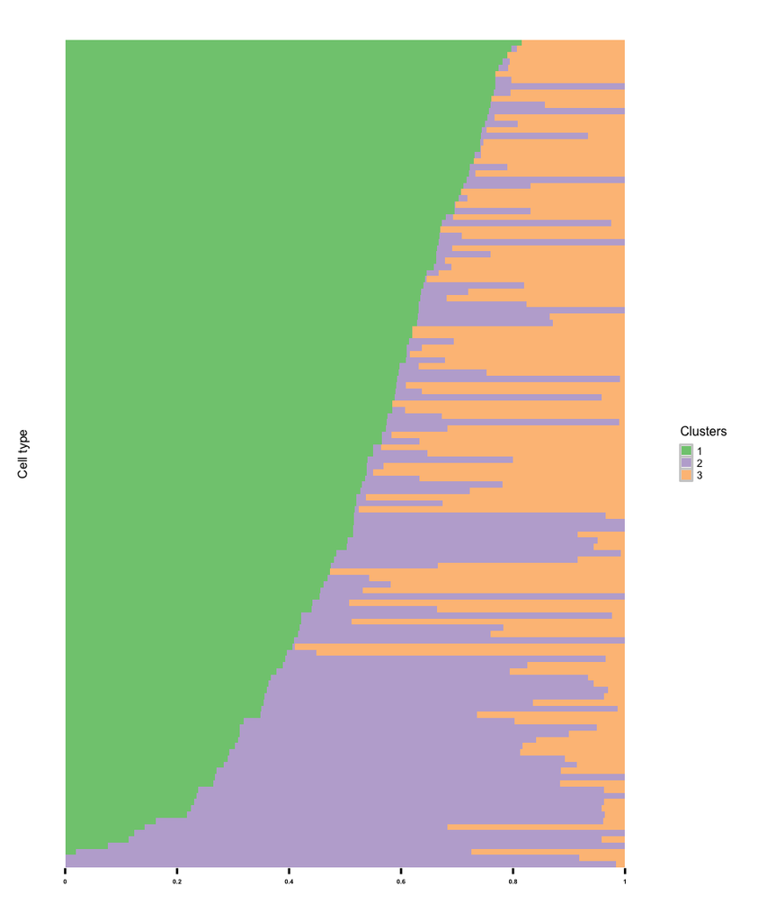

```r
# cell_type_blast <- as.character(meta_data$cell_type)
# cell_type_blast[grep("blast", cell_type_blast)] <- "blast"
# cell_type_blast <- factor(cell_type_blast,
#       levels = rev(c("zy", "early2cell", "mid2cell", "late2cell",
#                  "4cell", "8cell", "16cell", "blast")))
source("~/Dropbox/GitHub/CountClust/R/StructureGGplot.R")
StructureGGplot(omega = fit$omega,
    annotation = data.frame(
                   sample_id = paste0("X", c(1:NROW(fit$omega))),
                   tissue_label = rep("blast", NROW(fit$omega))),
               palette = RColorBrewer::brewer.pal(3, "Accent"),
               figure_title = "",
               yaxis_label = "Cell type",
               sample_order_decreasing = FALSE)
```

### Recover cell sample order

```r
source("../R/StructureGGplot-simple.R")
df_mlt <- StructureGGplot_simple(omega = fit$omega,
    annotation = data.frame(
                   sample_id = paste0("X", c(1:NROW(fit$omega))),
                   tissue_label = rep("blast", NROW(fit$omega))),
               palette = RColorBrewer::brewer.pal(3, "Accent"),
               figure_title = "",
               yaxis_label = "Cell type",
               sample_order_decreasing = FALSE)
structure_order_blast <- rev(as.character(df_mlt$document[!duplicated(df_mlt$document)]))
```

### Heatmap

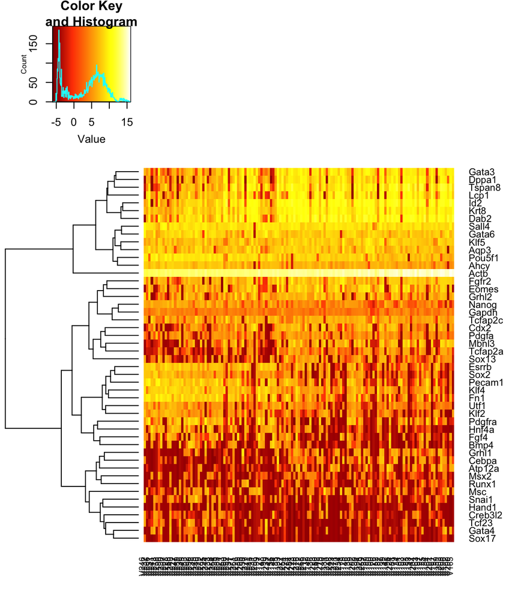

```r
colors <- seq(-6,16,length=220)
my_palette <- colorRampPalette(
    c("white", "yellow", "orange", "orangered", "red4"))(n = length(colors)-1)

xx <- as.matrix(expr_log2cpm_guo[,is_blastocyst])

gplots::heatmap.2(xx[, rev(structure_order_blast)],
                  breaks = colors,
                  col = rev(my_palette),
                  #labCol = "",
                  trace = "none",
                  dendrogram = "row", Colv = FALSE,
                  symm=F,symkey=F,symbreaks=T, scale="none",
                  main = "")
```

### Blastocyst labels

Summarize the blastocyst stages of the cell samples in the re-ordered dataset.

```r
meta_data_blast <- meta_data[grep("blast", meta_data$cell_type),]
meta_data_blast <- meta_data_blast[ match(rev(structure_order_blast), rownames(meta_data_blast)), ]
```

Make barplot to indicate blastocyst stages

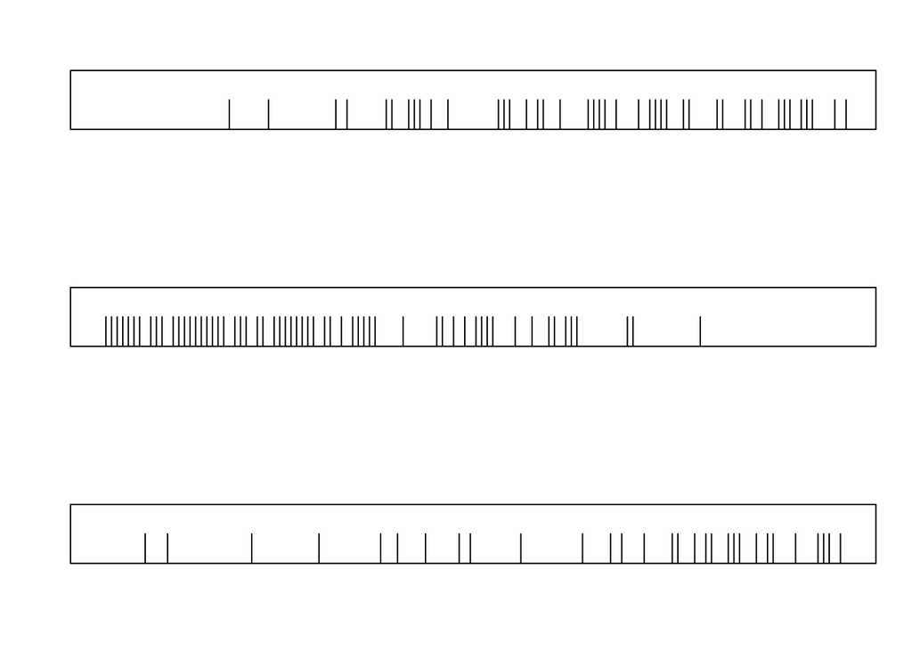

```r
par(mfrow = c(3,1))
for (i in c("earlyblast", "midblast", "lateblast")) {
    plot(x = which(meta_data_blast$cell_type == i),
         y = rep(1, length(which(meta_data_blast$cell_type == i))),
         type = "h", ann = FALSE, xaxt = "n", yaxt = "n",
         xlim = c(0,133))
}
```

### Extract top features

```r
source("~/Dropbox/GitHub/CountClust/R/ExtractTopFeatures.R")
top_features <- ExtractTopFeatures(fit$theta,
                               top_features = 5,
                               method = c("poisson"),
                               options=c("min"))
```

*Get gene description.*

Green cluster

```r
mygene::queryMany(attr(fit$theta, "dimnames")[["phrase"]][top_features[1,]],
                  scopes="symbol",
                  fields= c("query", "name", "description"),
                  species="mouse")
```

```
Finished
Pass returnall=TRUE to return lists of duplicate or missing query terms.
```

```
DataFrame with 5 rows and 4 columns
        query         _id        name  notfound
  <character> <character> <character> <logical>
1        Actb       11461 actin, beta        NA
2          NA          NA          NA      TRUE
3          NA          NA          NA      TRUE
4          NA          NA          NA      TRUE
5          NA          NA          NA      TRUE
```

Purple cluster

```r
mygene::queryMany(attr(fit$theta, "dimnames")[["phrase"]][top_features[2,]],
                  scopes="symbol",
                  fields= c("query", "name", "description"),
                  species="mouse")
```

```
Finished
```

```
DataFrame with 5 rows and 3 columns
          _id       query
  <character> <character>
1       18613      Pecam1
2       26380       Esrrb
3       14268         Fn1
4       18595      Pdgfra
5       20674        Sox2
                                                        name
                                                 <character>
1              platelet/endothelial cell adhesion molecule 1
2                            estrogen related receptor, beta
3                                              fibronectin 1
4 platelet derived growth factor receptor, alpha polypeptide
5                       SRY (sex determining region Y)-box 2
```

Orange cluster

```r
mygene::queryMany(attr(fit$theta, "dimnames")[["phrase"]][top_features[3,]],
                  scopes="symbol",
                  fields= c("query", "name", "description"),
                  species="mouse")
```

```
Finished
```

```
DataFrame with 5 rows and 3 columns
          _id                                          name       query
  <character>                                   <character> <character>
1      347708       developmental pluripotency associated 1       Dppa1
2       14462                        GATA binding protein 3       Gata3
3       15902                    inhibitor of DNA binding 2         Id2
4       13132 disabled 2, mitogen-responsive phosphoprotein        Dab2
5       18826                lymphocyte cytosolic protein 1        Lcp1
```

## K = 4

Load GoM results. Fitting k = 4 on the blastocyst samples and including 48 marker genes.

```r
fit_k4 <- get(load("../rdas/deng_guo_blast_48_genes_k_4.rda"))
```

### Make structure plot

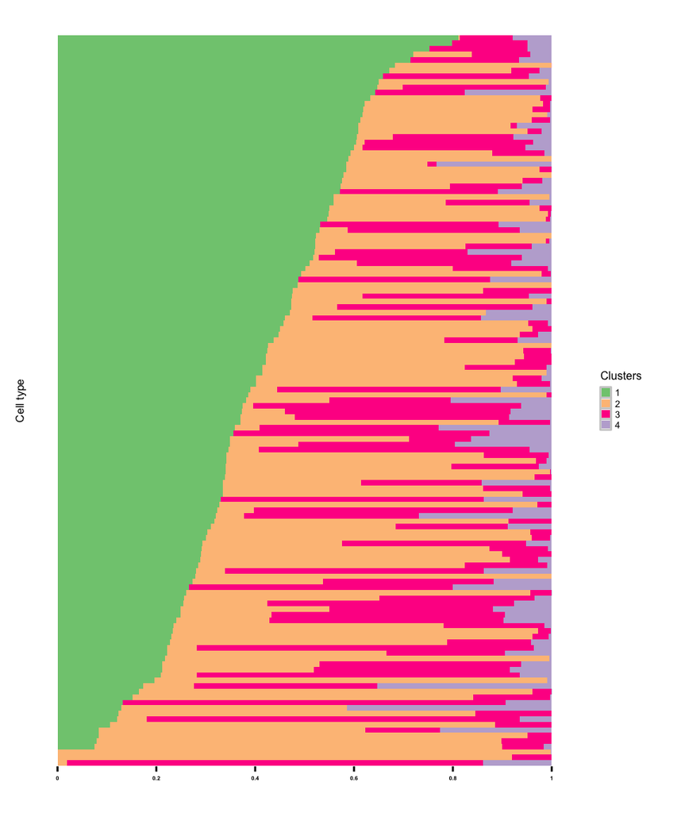

```r
# cell_type_blast <- as.character(meta_data$cell_type)
# cell_type_blast[grep("blast", cell_type_blast)] <- "blast"
# cell_type_blast <- factor(cell_type_blast,
#       levels = rev(c("zy", "early2cell", "mid2cell", "late2cell",
#                  "4cell", "8cell", "16cell", "blast")))
source("~/Dropbox/GitHub/CountClust/R/StructureGGplot.R")
StructureGGplot(omega = fit_k4$omega,
    annotation = data.frame(
                   sample_id = paste0("X", c(1:NROW(fit_k4$omega))),
                   tissue_label = rep("blast", NROW(fit_k4$omega))),
               palette = c(RColorBrewer::brewer.pal(3, "Accent"), "deeppink")[c(1,3,4,2)],
               figure_title = "",
               yaxis_label = "Cell type",
               sample_order_decreasing = FALSE)
```

### Recover cell sample order

```r
source("../R/StructureGGplot-simple.R")
df_mlt <- StructureGGplot_simple(omega = fit_k4$omega,
    annotation = data.frame(
                   sample_id = paste0("X", c(1:NROW(fit$omega))),
                   tissue_label = rep("blast", NROW(fit$omega))),
               palette = c(RColorBrewer::brewer.pal(3, "Accent"), "deeppink"),
               figure_title = "",
               yaxis_label = "Cell type",
               sample_order_decreasing = FALSE)
structure_order_blast <- rev(as.character(df_mlt$document[!duplicated(df_mlt$document)]))
```

### Heatmap

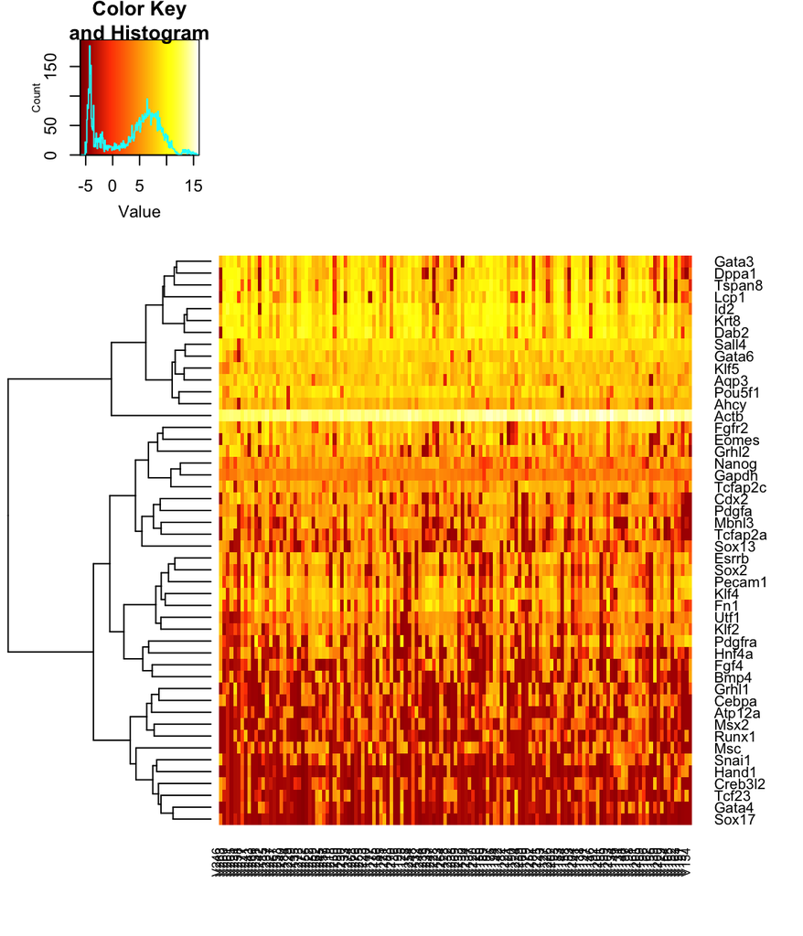

```r
colors <- seq(-6,16,length=220)
my_palette <- colorRampPalette(
    c("white", "yellow", "orange", "orangered", "red4"))(n = length(colors)-1)

xx <- as.matrix(expr_log2cpm_guo[,is_blastocyst])

gplots::heatmap.2(xx[, rev(structure_order_blast)],
                  breaks = colors,
                  col = rev(my_palette),
                  #labCol = "",
                  trace = "none",
                  dendrogram = "row", Colv = FALSE,
                  symm=F,symkey=F,symbreaks=T, scale="none",
                  main = "")
```

### Blastocyst labels

Summarize the blastocyst stages of the cell samples in the re-ordered dataset.

```r
meta_data_blast <- meta_data[grep("blast", meta_data$cell_type),]
meta_data_blast <- meta_data_blast[ match(rev(structure_order_blast), rownames(meta_data_blast)), ]
```

Make barplot to indicate blastocyst stages

[figure not shown]

```r
par(mfrow = c(3,1))
for (i in c("earlyblast", "midblast", "lateblast")) {
    plot(x = which(meta_data_blast$cell_type == i),
         y = rep(1, length(which(meta_data_blast$cell_type == i))),
         type = "h", ann = FALSE, xaxt = "n", yaxt = "n",
         xlim = c(0,133))
}
```

### Extract top features

```r
source("~/Dropbox/GitHub/CountClust/R/ExtractTopFeatures.R")
top_features <- ExtractTopFeatures(fit_k4$theta,
                               top_features = 5,
                               method = c("poisson"),
                               options=c("min"))
```

*Get gene description.*

Green cluster

```r
mygene::queryMany(attr(fit_k4$theta, "dimnames")[["phrase"]][top_features[1,]],
                  scopes="symbol",
                  fields= c("query", "name", "description"),
                  species="mouse")
```

```
Finished
Pass returnall=TRUE to return lists of duplicate or missing query terms.
```

```
DataFrame with 5 rows and 4 columns
         name         _id       query  notfound
  <character> <character> <character> <logical>
1 actin, beta       11461        Actb        NA
2          NA          NA          NA      TRUE
3          NA          NA          NA      TRUE
4          NA          NA          NA      TRUE
5          NA          NA          NA      TRUE
```

Orange cluster

```r
mygene::queryMany(attr(fit_k4$theta, "dimnames")[["phrase"]][top_features[2,]],
                  scopes="symbol",
                  fields= c("query", "name", "description"),
                  species="mouse")
```

```
Finished
```

```
DataFrame with 5 rows and 3 columns
                                           name       query         _id
                                    <character> <character> <character>
1       developmental pluripotency associated 1       Dppa1      347708
2                    inhibitor of DNA binding 2         Id2       15902
3                                 tetraspanin 8      Tspan8      216350
4 disabled 2, mitogen-responsive phosphoprotein        Dab2       13132
5                        GATA binding protein 3       Gata3       14462
```

Pink cluster

```r
mygene::queryMany(attr(fit_k4$theta, "dimnames")[["phrase"]][top_features[3,]],
                  scopes="symbol",
                  fields= c("query", "name", "description"),
                  species="mouse")
```

```
Finished
```

```
DataFrame with 5 rows and 3 columns
          _id       query
  <character> <character>
1       18999      Pou5f1
2       14465       Gata6
3       15378       Hnf4a
4       20613       Snai1
5       15110       Hand1
                                                       name
                                                <character>
1               POU domain, class 5, transcription factor 1
2                                    GATA binding protein 6
3                           hepatic nuclear factor 4, alpha
4                                snail family zinc finger 1
5 heart and neural crest derivatives expressed transcript 1
```

Purple cluster

```r
mygene::queryMany(attr(fit_k4$theta, "dimnames")[["phrase"]][top_features[4,]],
                  scopes="symbol",
                  fields= c("query", "name", "description"),
                  species="mouse")
```

```
Finished
```

```
DataFrame with 5 rows and 3 columns
          _id                                                       name
  <character>                                                <character>
1       18595 platelet derived growth factor receptor, alpha polypeptide
2       14268                                              fibronectin 1
3       14175                                 fibroblast growth factor 4
4       12159                               bone morphogenetic protein 4
5       18613              platelet/endothelial cell adhesion molecule 1
        query
  <character>
1      Pdgfra
2         Fn1
3        Fgf4
4        Bmp4
5      Pecam1
```

## PCA and t-SNE

### PCA

load PCA functions

```r
source("../R/plot-pca-functions.R")
```

```r
pca_48genes <- run_pca(expr_log2cpm_guo[, is_blastocyst])
pca_plots_48genes <- plot_pca(
    x = pca_48genes$PCs,
    metadata = meta_data[is_blastocyst, ],
    explained = pca_48genes$explained,
    color = "cell_type",
    factors = "cell_type")
```

### t-SNE

```r
library(tsne)
tsne_48genes <- tsne(t(expr_log2cpm_guo[, is_blastocyst]),
#                     epoch_callback = ecb,
                     perplexity=50)
tsne_48genes <- data.frame(tsne_48genes)
colnames(tsne_48genes) <- c("dim1","dim2")
tsne_48genes <- data.frame(tsne_48genes,
                           cell_type = meta_data[is_blastocyst, ]$cell_type)

tsne_plots_48genes <-
  ggplot(data = tsne_48genes,
         mapping = aes(x = dim1, y = dim2, color = as.factor(cell_type))) +
  geom_point() +
  ylab("2nd dimension") + xlab("1st dimension")
```

### Combined plot

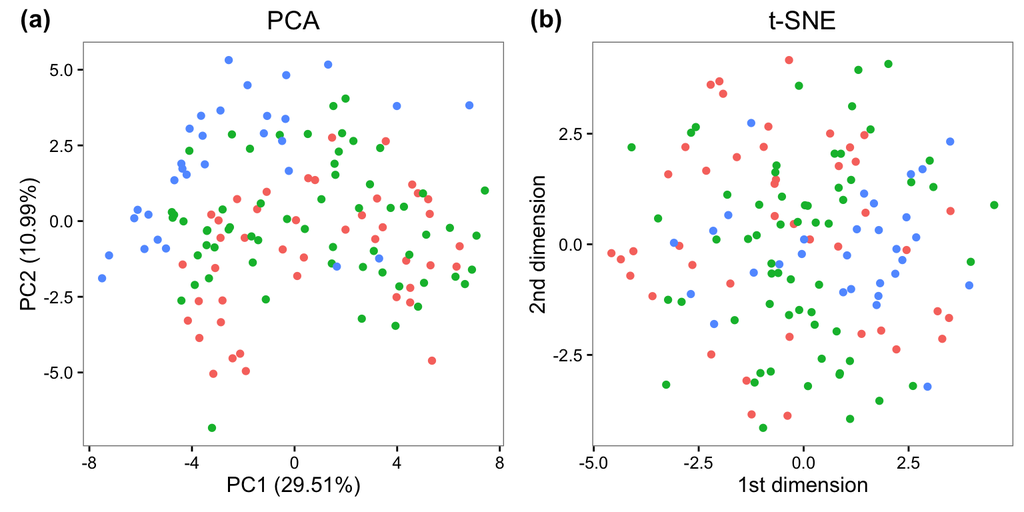

```r
cowplot::plot_grid(
  pca_plots_48genes + ggtitle("PCA") + theme(legend.position="none"),
  tsne_plots_48genes + ggtitle("t-SNE")  + theme(legend.position="none"),
  labels = c("(a)", "(b)"))
```

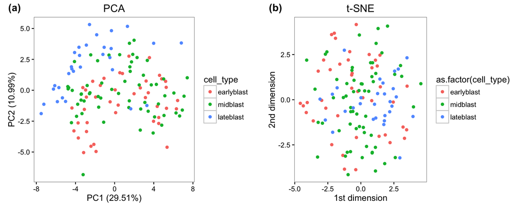

```r
cowplot::plot_grid(
  pca_plots_48genes + ggtitle("PCA"),
  tsne_plots_48genes + ggtitle("t-SNE"),
  labels = c("(a)", "(b)"))
```